**NOTE: Before running this notebook, place a copy of your downloaded RomeoAndJuliet.txt file in the same folder with this notebook.**

# 12.3 Visualizing Word Frequencies with Bar Charts and Word Clouds

- Can enhance your corpus analyses
  - A **bar chart** **quantitatively** visualizes the top 20 words in Romeo and Juliet as bars representing each word and its frequency.
  - A **word cloud** **qualitatively** visualizes more frequently occurring words in larger fonts and less frequently occurring words in smaller fonts.

## 12.3.1 Visualizing Word Frequencies with Pandas

- Visualize **Romeo and Juliet**’s top 20 words that are **not stop words**, using features from **TextBlob**, **NLTK** and **pandas**.
- Pandas visualization capabilities are based on Matplotlib, so launch IPython with the following command for this session:

  > ```
  > ipython --matplotlib
  > ```

- Or enable matplotlib in Jupyter

```python
%matplotlib inline
```

### Loading the Data

```python
from pathlib import Path
```

```python
from textblob import TextBlob
```

```python
blob = TextBlob(Path('RomeoAndJuliet.txt').read_text())
```

- Load NLTK stop words

```python
from nltk.corpus import stopwords
```

```python
stop_words = stopwords.words('english')
```

### Getting the Word Frequencies

- Get word frequency tuples

```python
items = blob.word_counts.items()
```

### Eliminating the Stop Words

- The expression `item[0]` gets the word from each tuple so we can check whether it’s in `stop_words`

```python
items = [item for item in items if item[0] not in stop_words]
```

### Sorting the Words by Frequency

- Sort the tuples in items in descending order by frequency
- To specify the tuple element to sort by, use the `itemgetter` function from the Python Standard Library’s `operator` module

```python
from operator import itemgetter
```

```python
sorted_items = sorted(items, key=itemgetter(1), reverse=True)
```

### Getting the Top 20 Words

- `TextBlob` tokenizaton splits all **contractions** at their **apostrophes** and **counts** the total number of **apostrophes** as one of the “words”
- **Romeo and Juliet** has many contractions
  - If you display `sorted_items[0]`, you’ll see that they are the most frequently occurring “word” with `867` of them
  - (In some **locales** this does not happen and element 0 is indeed `'romeo'`)
  - We ignore element `0`

```python
top20 = sorted_items[1:21]
```

### Convert top20 to a DataFrame

```python
import pandas as pd
```

```python
df = pd.DataFrame(top20, columns=['word', 'count'])
```

```python
df
```

|  | word | count |
| --- | --- | --- |
| 0 | romeo | 315 |
| 1 | thou | 278 |
| 2 | juliet | 190 |
| 3 | thy | 170 |
| 4 | capulet | 163 |
| 5 | nurse | 149 |
| 6 | love | 148 |
| 7 | thee | 138 |
| 8 | lady | 117 |
| 9 | shall | 110 |
| 10 | friar | 105 |
| 11 | come | 94 |
| 12 | mercutio | 88 |
| 13 | lawrence | 82 |
| 14 | good | 80 |
| 15 | benvolio | 79 |
| 16 | tybalt | 79 |
| 17 | enter | 75 |
| 18 | go | 75 |
| 19 | night | 73 |

### Visualizing the DataFrame

- **`bar` method** of the `DataFrame`’s **`plot` property** creates and displays a **Matplotlib bar chart**

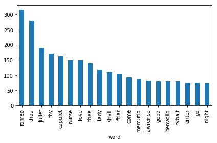

```python
axes = df.plot.bar(x='word', y='count', legend=False)

import matplotlib.pyplot as plt

plt.gcf().tight_layout()
```